# Statistische Auswertung mit R

Jannis Bosch

## Setup

- Bitte erstellt wieder ein R Projekt und öffnet es
- Erstellt ein R-Skript für den heutigen Workshop
- Erstellt in dem Projekt-Ordner einen neuen Ordner mit dem Namen dateien und speichert den Datensatz gleich dort

## Daten herunterladen

Hier klicken um den Datensatz runterzuladen

## Daten einlesen

```r
# Lest zunächst den Datensatz ein...
#download.file(file.path("https://jannisbosch.github.io/R-Tutorial/dateien/experiment_data.rds"), destfile = file.path("dateien", "experiment_data.rds"))

mydata <- readRDS(file.path("dateien", "experiment_data.rds"))

# ... und inspiziert ihn
```

# Exkurs: R-Bibliotheken

## psych

- Die psych-Bibliothek beinhaltet verschiedenste Funktionen für die Datenauswertung, Ausreißeranalyse und zur Test- und Fragebogenkonstruktion (Faktorenanalyse, Cronbach’s Alpha, etc.)
- Unter https://personality-project.org/r/psych/ kann man weitere Informationen zur psych-Bibliothek finden

## sjPlot

- Die sjPlot-Bibliothek beinhalten Funktionen, um Tabellen und Graphen für häufige Auswertungsmethoden (z.B. Korrelationen und Regressionsanalysen) zu erstellen
- Mehr Informationen unter https://strengejacke.github.io/sjPlot/

## tidyverse

- Das tidyverse ist eine Sammlung von Bibliotheken zur Datenanalyse
- Es beinhaltet verschiedene Bibliotheken und Funktionen, die die Datenaufbereitung erleichtern, Tools zur Erstellung von Graphiken (ggplot) und vieles mehr
- Mehr Informationen unter https://www.tidyverse.org/

## R Cheat Sheets

- Cheat Sheets sind eine graphische Aufbereitung verschiedener Funktionen von Bibliotheken
- [dplyr Cheat Sheet](https://nyu-cdsc.github.io/learningr/assets/data-transformation.pdf)
- [tidyr Cheat Sheet](https://raw.githubusercontent.com/rstudio/cheatsheets/main/tidyr.pdf)

## Biblotheken installieren

```r
# Die Bibliotheken installieren
install.packages("tidyverse")
install.packages("sjPlot")
install.packages("psych")
# Das muss man an jedem Computer nur einmal ausführen
```

```r
# Und die Bibliotheken laden
library(tidyverse)
library(sjPlot)
library(psych)
# Das muss man bei jedem Neustart von R erneut ausführen
```

# Datenaufbereitung mit dplyr

## Skalen bilden

```r
# Wir nutzen die pipe und die mutate-Funktion aus der dplyr-Bibliothek, um neue Variablen zu definieren
# Die pipe nutzt die Variable vor der pipe |> als erstes Argument für die Funktion nach der pipe |>

mydata <- mydata |>
  group_by(UserID) |>
  mutate(
    sc1mean = mean(c(sc1_1, sc1_2_rev, sc1_3, sc1_4_rev), na.rm = T),
    sc2mean = mean(c(sc2_1, sc2_2_rev, sc2_3, sc2_4_rev), na.rm = T),
    int1mean = mean(c(int1_1, int1_2, int1_3, int1_4), na.rm = T),
    int2mean = mean(c(int2_1, int2_2, int2_3, int2_4), na.rm = T)
  ) |>
  ungroup()

# Wir sagen R, dass wir die folgenden Berechnungen pro UserID durchführen wollen (group_by)
# Wir berechnen die Skalenmittelwerte (pro Person) (mutate)
# Wir heben die Gruppierung des Datensatzes wieder auf (ungroup)
```

## Datensatz aufräumen

```r
# Für die heutigen Berechnungen benötigen wir nur einen Teil des Datensatzes
# Deswegen nutzten wir die select-Funktion, um den Datensatz aufzuräumen

mydata_scales <- mydata |>
  select(UserID, sozpos, sc1mean, sc2mean, int1mean, int2mean)
# Wir erstellen einen reduzierten Datensatz und nennen ihn mydata_scales
# Er beinhaltet nur die UserID, die experimentellen Gruppen und die berechneten Skalenmittelwerte
```

## Einen Überblick über die Daten bekommen

```r
# Die describe-Funktion bietet einen Überblick über die Daten
mydata_scales |>
  describe()
```

```
         vars   n    mean    sd  median trimmed   mad    min  max range  skew
UserID      1 166 1114.83 54.37 1115.50 1115.03 68.94 1020.0 1209 189.0 -0.02
sozpos*     2 166    1.51  0.50    2.00    1.51  0.00    1.0    2   1.0 -0.02
sc1mean     3 166    4.20  1.25    4.25    4.24  1.48    1.5    7   5.5 -0.16
sc2mean     4 166    4.02  1.28    4.00    4.03  1.11    1.0    7   6.0 -0.16
int1mean    5 166    4.29  1.46    4.50    4.36  1.48    1.0    7   6.0 -0.41
int2mean    6 166    4.27  1.59    4.50    4.36  1.48    1.0    7   6.0 -0.45
         kurtosis   se
UserID      -1.17 4.22
sozpos*     -2.01 0.04
sc1mean     -0.92 0.10
sc2mean     -0.45 0.10
int1mean    -0.71 0.11
int2mean    -0.73 0.12
```

## Gruppen vergleichen

```r
#...und das auch getrennt für beide Experimentalgruppen
mydata_scales |>
  describeBy(group = "sozpos")
```

```
 Descriptive statistics by group
sozpos: 1
         vars  n    mean    sd  median trimmed   mad     min  max  range  skew
UserID      1 82 1116.43 53.09 1121.00 1117.03 63.01 1021.00 1209 188.00 -0.12
sozpos      2 82    1.00  0.00    1.00    1.00  0.00    1.00    1   0.00   NaN
sc1mean     3 82    4.12  1.26    4.00    4.15  1.48    1.75    7   5.25 -0.10
sc2mean     4 82    3.72  1.26    3.88    3.70  1.30    1.00    7   6.00 -0.02
int1mean    5 82    4.38  1.51    4.50    4.45  1.48    1.00    7   6.00 -0.40
int2mean    6 82    4.21  1.61    4.25    4.27  1.48    1.00    7   6.00 -0.30
         kurtosis   se
UserID      -1.08 5.86
sozpos        NaN 0.00
sc1mean     -1.03 0.14
sc2mean     -0.66 0.14
int1mean    -0.61 0.17
int2mean    -0.71 0.18
------------------------------------------------------------
sozpos: 2
         vars  n    mean    sd  median trimmed   mad    min    max range  skew
UserID      1 84 1113.27 55.86 1110.00 1113.09 70.42 1020.0 1208.0 188.0  0.08
sozpos      2 84    2.00  0.00    2.00    2.00  0.00    2.0    2.0   0.0   NaN
sc1mean     3 84    4.28  1.24    4.25    4.32  1.48    1.5    6.5   5.0 -0.21
sc2mean     4 84    4.31  1.24    4.25    4.35  1.11    1.0    7.0   6.0 -0.30
int1mean    5 84    4.21  1.41    4.50    4.28  1.48    1.0    6.5   5.5 -0.45
int2mean    6 84    4.32  1.58    4.75    4.44  1.48    1.0    7.0   6.0 -0.60
         kurtosis   se
UserID      -1.28 6.10
sozpos        NaN 0.00
sc1mean     -0.85 0.13
sc2mean     -0.12 0.13
int1mean    -0.93 0.15
int2mean    -0.77 0.17
```

# Korrelationen berechnen

## Die cor-Funktion

```r
# Korrelationen können wir mit der corr.test-Funktion aus der psych-Bibliothek berechnen
mydata_scales |>
  select(sc1mean, sc2mean, int1mean, int2mean) |>
  corr.test()
```

```
Call:corr.test(x = select(mydata_scales, sc1mean, sc2mean, int1mean,
    int2mean))
Correlation matrix
         sc1mean sc2mean int1mean int2mean
sc1mean     1.00    0.86     0.42     0.41
sc2mean     0.86    1.00     0.46     0.47
int1mean    0.42    0.46     1.00     0.90
int2mean    0.41    0.47     0.90     1.00
Sample Size
[1] 166
Probability values (Entries above the diagonal are adjusted for multiple tests.)
         sc1mean sc2mean int1mean int2mean
sc1mean        0       0        0        0
sc2mean        0       0        0        0
int1mean       0       0        0        0
int2mean       0       0        0        0

 To see confidence intervals of the correlations, print with the short=FALSE option
```

## Die tab_corr-Funktion

```r
# Mit der sjPlot-Bibliothek können wir uns das ganze tabellarisch aufbereiten lassen
mydata_scales |>
  select(sc1mean, sc2mean, int1mean, int2mean) |>
  tab_corr()
```

|  | sc1mean | sc2mean | int1mean | int2mean |
| --- | --- | --- | --- | --- |
| sc1mean |  | 0.858*** | 0.421*** | 0.407*** |
| sc2mean | 0.858*** |  | 0.456*** | 0.470*** |
| int1mean | 0.421*** | 0.456*** |  | 0.897*** |
| int2mean | 0.407*** | 0.470*** | 0.897*** |  |
| Computed correlation used pearson-method with listwise-deletion. |  |  |  |  |

```r
# In der Hilfe-Datei können wir uns die tab_corr-Funktion genauer anschauen
#?tab_corr
```

## Die tab_corr-Funktion

```r
# Wir können die Ausgabe auch entsprechend unseren Vorstellungen anpassen und als HTML-Tabelle speichern
mydata_scales |>
  select(sc1mean, sc2mean, int1mean, int2mean) |>
  tab_corr(p.numeric = T, digits = 2, triangle = "lower", title = "Meine Korrelationstabelle", var.labels = c("Selbstkonzept (Pre)", "Selbstkonzept (Post)", "Interesse (Pre)", "Interesse (Post)"), file = "Meine Korrelationstabelle.html")

# Die HTML-Tabelle könnt ihr mit copy-paste auch in ein Word-Dokument einfügen
```

## Korrelationen grafisch darstellen

```r
mydata_scales |>
  plot_scatter(sc1mean, sc2mean, fit.line = "lm")
```

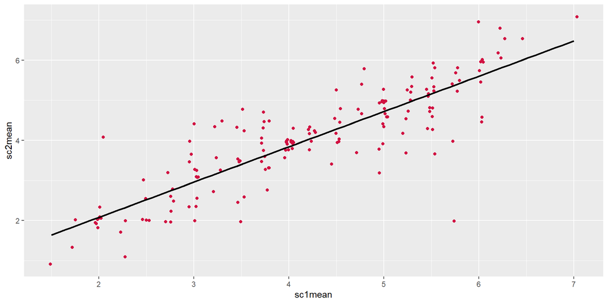

# Regressionsanalysen berechnen

## Die (einfache) lineare Regression

```r
# Zusammenhänge können natürlich auch per Regressionsanalyse
# betrachtet werden. Hier wurde der Zusammenhang zwischen dem Selbstkonzept
# zum ersten und zweiten Messzeitpunkt mit der lm()-Funktion berechnet
lm(sc2mean ~ sc1mean, data = mydata_scales)
```

```
Call:
lm(formula = sc2mean ~ sc1mean, data = mydata_scales)

Coefficients:
(Intercept)      sc1mean
     0.3185       0.8802
```

## Die (einfache) lineare Regression

```r
# Die summary()-Funktion liefert etwas ausführlichere Ergebnisse
summary(lm(sc2mean ~ sc1mean, data = mydata_scales))
```

```
Call:
lm(formula = sc2mean ~ sc1mean, data = mydata_scales)

Residuals:
    Min      1Q  Median      3Q     Max
-3.3794 -0.3616  0.0906  0.3107  1.9212

Coefficients:
            Estimate Std. Error t value Pr(>|t|)
(Intercept)  0.31849    0.18028   1.767   0.0792 .
sc1mean      0.88016    0.04113  21.400   <2e-16 ***
---
Signif. codes:  0 '***' 0.001 '**' 0.01 '*' 0.05 '.' 0.1 ' ' 1

Residual standard error: 0.6588 on 164 degrees of freedom
Multiple R-squared:  0.7363,    Adjusted R-squared:  0.7347
F-statistic: 457.9 on 1 and 164 DF,  p-value: < 2.2e-16
```

```r
# Interpretation:
# Intercept - Wenn alle Prädiktoren einen Wert von 0 haben (in diesem
# Fall also wenn sc1mean 0 ist), erwarten wir einen Wert von 0.319
# für das Kriterium (sc2mean)
```

## Die (einfache) lineare Regression

```r
# Man kann sich auch einzelne Elemente aus der Ausgabe anzeigen lassen
summary(lm(sc2mean ~ sc1mean, data = mydata_scales))[["coefficients"]]
```

```
             Estimate Std. Error   t value     Pr(>|t|)
(Intercept) 0.3184855 0.18028385  1.766578 7.915918e-02
sc1mean     0.8801597 0.04112954 21.399697 2.447987e-49
```

```r
# Das Intercept ist immer der vorhergesagte Wert für das Kriterium (hier sc2mean)
# wenn alle Prädiktoren (hier sc1mean) den Wert 0 haben. Jeder Erhöhung um einen Punkt
# in der Prädiktorvariable erhöht den vorhergesagten Wert für das Kriterium um das zugehörige
# b-Gewicht (Estimate)
# Das Modell sagt also aus:
# Eine Person mit einem Selbstkonzept von 0 im Pre-Test würde das Modell einen Post-Test Wert
# von (Intercept)
round(summary(lm(sc2mean ~ sc1mean, data = mydata_scales))[["coefficients"]][1,"Estimate"], 2)
```

```
[1] 0.32
```

```r
# vorhersagen. Einer Person mit einem Pre-Test Selbstkonzept von 2 würde das Modell
# einen Post-Test Wert von (Intercept + 2 * Regressionsgewicht sc1mean)
round(summary(lm(sc2mean ~ sc1mean, data = mydata_scales))[["coefficients"]][1,"Estimate"] + 2 * summary(lm(sc2mean ~ sc1mean, data = mydata_scales))[["coefficients"]][2,"Estimate"], 2)
```

```
[1] 2.08
```

```r
# vorhersagen.
```

## Die (einfache) lineare Regression

```r
# Diese Informationen kann man theoretisch auch aus der Grafik ablesen
# Ich habe hier mit dem Plus-Zeichen noch ein paar Optionen in der ggplot-Grafik verändert
mydata_scales |>
  plot_scatter(sc1mean, sc2mean, fit.line = "lm") +
  coord_cartesian(xlim = c(0, 7), ylim = c(0, 7)) +
  scale_y_continuous(breaks = seq(0, 7, by = 1)) +
  scale_x_continuous(breaks = seq(0, 7, by = 1))
```

```r
# Intercept / Y-Achsen-Abschnitt: 0.318
# Prädiktor sc1mean / Steigung: 0.880
# Vorhersage bei Personen mit sc1mean = 2: 2.08
```

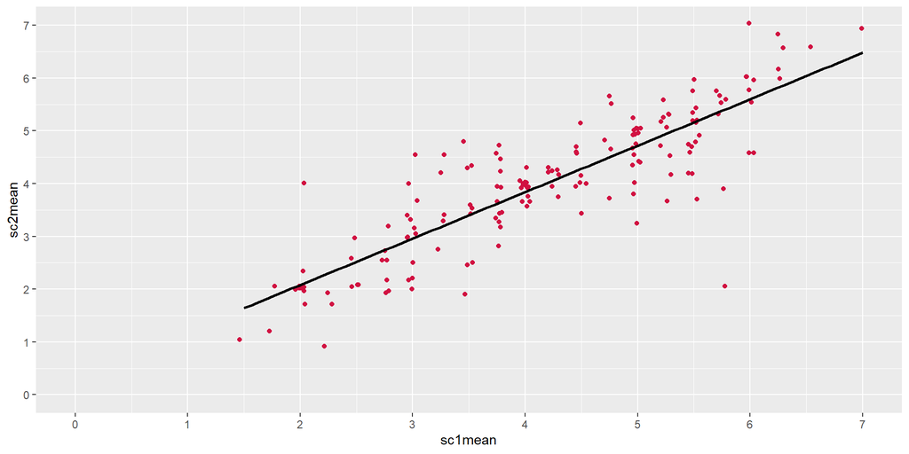

## Die (einfache) lineare Regression

```r
# Aus dem Regressionsmodell lässt sich auch die Korrelation ableiten.
# Zumindest im einfachsten Fall mit einem Kriterium und einem Prädiktor ist die
# Korrelation r die Wurzel aus dem R²
sqrt(summary(lm(sc2mean ~ sc1mean, data = mydata_scales))[["r.squared"]])
```

```
[1] 0.8580862
```

```r
# Zum Vergleich
corr.test(mydata_scales[,c("sc1mean", "sc2mean")])
```

```
Call:corr.test(x = mydata_scales[, c("sc1mean", "sc2mean")])
Correlation matrix
        sc1mean sc2mean
sc1mean    1.00    0.86
sc2mean    0.86    1.00
Sample Size
[1] 166
Probability values (Entries above the diagonal are adjusted for multiple tests.)
        sc1mean sc2mean
sc1mean       0       0
sc2mean       0       0

 To see confidence intervals of the correlations, print with the short=FALSE option
```

## Die (einfache) lineare Regression

```r
# Regressionsergebnisse können wir uns mit der sjPlot-Bibliothek auch "publikationsfertig" ausgeben lassen
mymodel <- lm(sc2mean ~ sc1mean, data = mydata_scales)
tab_model(mymodel)
```

|  | sc2mean |  |  |
| --- | --- | --- | --- |
| Predictors | Estimates | CI | p |
| (Intercept) | 0.32 | -0.04 – 0.67 | 0.079 |
| sc1mean | 0.88 | 0.80 – 0.96 | **<0.001** |
| Observations | 166 |  |  |
| R<sup>2</sup> / R<sup>2</sup> adjusted | 0.736 / 0.735 |  |  |

```r
#?tab_model
```

## Die (einfache) lineare Regression

```r
# Mit Hilfe der Optionen können wir das ganze noch anpassen
tab_model(mymodel, show.std = T, file = "mytable.html")
```

|  | sc2mean |  |  |  |  |
| --- | --- | --- | --- | --- | --- |
| Predictors | Estimates | std. Beta | CI | standardized CI | p |
| (Intercept) | 0.32 | -0.00 | -0.04 – 0.67 | -0.08 – 0.08 | 0.079 |
| sc1mean | 0.88 | 0.86 | 0.80 – 0.96 | 0.78 – 0.94 | **<0.001** |
| Observations | 166 |  |  |  |  |
| R<sup>2</sup> / R<sup>2</sup> adjusted | 0.736 / 0.735 |  |  |  |  |

## Die (einfache) lineare Regression

```r
# Das standardisierte Beta entspricht wieder der Korrelation
# Zum Vergleich
corr.test(mydata_scales[,c("sc1mean", "sc2mean")])
```

```
Call:corr.test(x = mydata_scales[, c("sc1mean", "sc2mean")])
Correlation matrix
        sc1mean sc2mean
sc1mean    1.00    0.86
sc2mean    0.86    1.00
Sample Size
[1] 166
Probability values (Entries above the diagonal are adjusted for multiple tests.)
        sc1mean sc2mean
sc1mean       0       0
sc2mean       0       0

 To see confidence intervals of the correlations, print with the short=FALSE option
```

# Komplexere Gruppenvergleiche

## Multiple Regression

```r
# Fragestellung: Unterscheidet sich der Anstieg des Interesses von Pre-
# zu Post-Messung zwischen den Untersuchungsgruppen?
#
# Wie könnten wir vorgehen, um die Frage zu beantworten?
```

## Multiple Regression

```r
# Zunächst bestimmen wir die Kontraste
contrasts(mydata_scales[["sozpos"]]) <- c(0,1)
# Weiß noch jemand was das für unser Modell bedeutet?

# Nullmodell zum Vergleich
model0 <- lm(int2mean ~ 1, data = mydata_scales)

# So sagen wir anhand der Gruppe den Wert zum Posttest vorher:
model1 <- lm(int2mean ~ sozpos, data = mydata_scales)

# So sagen wir anhand der Gruppe den anhand des Wertes zum Prä-Test
# korrigierten Wert zum Posttest vorher:
model2 <- lm(int2mean ~ sozpos + int1mean, data = mydata_scales)

# Disclaimer: Man kann so vorgehen, besser wäre aber bei ausreichender Stichprobengröße
# ein Mehrebenen-Modell! Dieses Beispiel ist nur zur Veranschaulichung.
```

## Multiple Regression

```r
summary(model0)
```

```
Call:
lm(formula = int2mean ~ 1, data = mydata_scales)

Residuals:
    Min      1Q  Median      3Q     Max
-3.2681 -1.0181  0.2319  1.2319  2.7319

Coefficients:
            Estimate Std. Error t value Pr(>|t|)
(Intercept)   4.2681     0.1237   34.51   <2e-16 ***
---
Signif. codes:  0 '***' 0.001 '**' 0.01 '*' 0.05 '.' 0.1 ' ' 1

Residual standard error: 1.593 on 165 degrees of freedom
```

```r
# Interpretation?
```

## Multiple Regression

```r
summary(model0)
```

```
Call:
lm(formula = int2mean ~ 1, data = mydata_scales)

Residuals:
    Min      1Q  Median      3Q     Max
-3.2681 -1.0181  0.2319  1.2319  2.7319

Coefficients:
            Estimate Std. Error t value Pr(>|t|)
(Intercept)   4.2681     0.1237   34.51   <2e-16 ***
---
Signif. codes:  0 '***' 0.001 '**' 0.01 '*' 0.05 '.' 0.1 ' ' 1

Residual standard error: 1.593 on 165 degrees of freedom
```

```r
# Interpretation: Der Mittelwert des Interesses (Post-Test) beträgt ca. 4.27.
mean(mydata_scales[["int2mean"]], na.rm = T)
```

```
[1] 4.268072
```

## Multiple Regression

```r
summary(model1)
```

```
Call:
lm(formula = int2mean ~ sozpos, data = mydata_scales)

Residuals:
    Min      1Q  Median      3Q     Max
-3.3244 -0.9604  0.2326  1.2611  2.7896

Coefficients:
            Estimate Std. Error t value Pr(>|t|)
(Intercept)   4.2104     0.1764   23.87   <2e-16 ***
sozpos1       0.1140     0.2480    0.46    0.646
---
Signif. codes:  0 '***' 0.001 '**' 0.01 '*' 0.05 '.' 0.1 ' ' 1

Residual standard error: 1.597 on 164 degrees of freedom
Multiple R-squared:  0.001288,  Adjusted R-squared:  -0.004802
F-statistic: 0.2115 on 1 and 164 DF,  p-value: 0.6462
```

```r
# Interpretation?
```

## Multiple Regression

```r
summary(model1)
```

```
Call:
lm(formula = int2mean ~ sozpos, data = mydata_scales)

Residuals:
    Min      1Q  Median      3Q     Max
-3.3244 -0.9604  0.2326  1.2611  2.7896

Coefficients:
            Estimate Std. Error t value Pr(>|t|)
(Intercept)   4.2104     0.1764   23.87   <2e-16 ***
sozpos1       0.1140     0.2480    0.46    0.646
---
Signif. codes:  0 '***' 0.001 '**' 0.01 '*' 0.05 '.' 0.1 ' ' 1

Residual standard error: 1.597 on 164 degrees of freedom
Multiple R-squared:  0.001288,  Adjusted R-squared:  -0.004802
F-statistic: 0.2115 on 1 and 164 DF,  p-value: 0.6462
```

```r
# Interpretation: Der Mittelwert des Interesses (Post-Test) in der low social position Gruppe (Referenzgruppe) beträgt ca. 4.21.
# Für die high social position Gruppe wird darauf ca. 0.11 aufaddiert.
```

## Multiple Regression

```r
# Das stimmt auch mathematisch mit den Mitelwerten der Gruppen überein:
mydata_scales |>
  group_by(sozpos) |>
  summarize(
    mean_int2 = mean(int2mean)
  )
```

```
# A tibble: 2 × 2
  sozpos               mean_int2
  <fct>                    <dbl>
1 low social position       4.21
2 high social position      4.32
```

## Multiple Regression

```r
summary(model2)
```

```
Call:
lm(formula = int2mean ~ sozpos + int1mean, data = mydata_scales)

Residuals:
    Min      1Q  Median      3Q     Max
-3.2994 -0.3308  0.1295  0.3846  3.3623

Coefficients:
            Estimate Std. Error t value Pr(>|t|)
(Intercept) -0.11272    0.18038  -0.625   0.5329
sozpos1      0.27868    0.10817   2.576   0.0109 *
int1mean     0.98745    0.03728  26.488   <2e-16 ***
---
Signif. codes:  0 '***' 0.001 '**' 0.01 '*' 0.05 '.' 0.1 ' ' 1

Residual standard error: 0.6956 on 163 degrees of freedom
Multiple R-squared:  0.8117,    Adjusted R-squared:  0.8094
F-statistic: 351.4 on 2 and 163 DF,  p-value: < 2.2e-16
```

```r
# Interpretation?
```

## Multiple Regression

```r
summary(model2)
```

```
Call:
lm(formula = int2mean ~ sozpos + int1mean, data = mydata_scales)

Residuals:
    Min      1Q  Median      3Q     Max
-3.2994 -0.3308  0.1295  0.3846  3.3623

Coefficients:
            Estimate Std. Error t value Pr(>|t|)
(Intercept) -0.11272    0.18038  -0.625   0.5329
sozpos1      0.27868    0.10817   2.576   0.0109 *
int1mean     0.98745    0.03728  26.488   <2e-16 ***
---
Signif. codes:  0 '***' 0.001 '**' 0.01 '*' 0.05 '.' 0.1 ' ' 1

Residual standard error: 0.6956 on 163 degrees of freedom
Multiple R-squared:  0.8117,    Adjusted R-squared:  0.8094
F-statistic: 351.4 on 2 and 163 DF,  p-value: < 2.2e-16
```

```r
# Interpretation: Wenn in1_mean 0 ist, ist der Erwartungswert für das Interesse beim Post-Test in der low social position Gruppe (Referenzgruppe) ca. -0.11.
# Für jeden Punkt höher als 0 im Prä-Test Interesse werden darauf ca. 0.99 Punkt aufaddiert.
# Für Personen in der high social position Gruppe werden zusätzlich ca. 0.28 aufaddiert.
```

## Multiple Regression

```r
# Erklärt das jeweils komplexere Modell die Daten
# wirklich besser als die jeweils einfacheren Modelle?
# Oder: Steigt das R-Quadrat signifikant an?
anova(model0, model1, model2)
```

```
Analysis of Variance Table

Model 1: int2mean ~ 1
Model 2: int2mean ~ sozpos
Model 3: int2mean ~ sozpos + int1mean
  Res.Df    RSS Df Sum of Sq        F Pr(>F)
1    165 418.95
2    164 418.41  1      0.54   1.1151 0.2925
3    163  78.88  1    339.53 701.6337 <2e-16 ***
---
Signif. codes:  0 '***' 0.001 '**' 0.01 '*' 0.05 '.' 0.1 ' ' 1
```

```r
# In diesem Fall würde es naheliegen sich für model2 zu entscheiden.
```

## Übungsaufgabe

- Führt die eben gezeigten Analysen mit dem Selbstkonzept durch und interpretiert die Ergebnisse

## Lösung

- Auf der nächsten Folie kommt die Lösung :)

## Lösung

```r
# Nullmodell:
model0sc <- lm(sc2mean ~ 1, data = mydata_scales)

# Hier werden wieder die Post-Test Werte anhand der Gruppe
# vorhergesagt:
model1sc <- lm(sc2mean ~ sozpos, data = mydata_scales)
# oder: model1sc <- update(model0sc, .~. + sozpos)

# Hier wird wieder für die Prä-Test Werte korrigiert:
model2sc <- lm(sc2mean ~ sozpos + sc1mean, data = mydata_scales)
# oder: model2sc <- update(model1sc, .~. + sc1mean)
```

## Lösung - Modell 0

```r
summary(model0sc)
```

```
Call:
lm(formula = sc2mean ~ 1, data = mydata_scales)

Residuals:
     Min       1Q   Median       3Q      Max
-3.01807 -0.76807 -0.01807  0.91943  2.98193

Coefficients:
            Estimate Std. Error t value Pr(>|t|)
(Intercept)  4.01807    0.09928   40.47   <2e-16 ***
---
Signif. codes:  0 '***' 0.001 '**' 0.01 '*' 0.05 '.' 0.1 ' ' 1

Residual standard error: 1.279 on 165 degrees of freedom
```

```r
# Interpretation: Der Mittelwert im Selbstkonzept (Post-Test) beträgt ca. 4
# über beide Gruppen hinweg.
```

## Lösung - Modell 1

```r
summary(model1sc)
```

```
Call:
lm(formula = sc2mean ~ sozpos, data = mydata_scales)

Residuals:
    Min      1Q  Median      3Q     Max
-3.3065 -0.8065  0.0274  0.9435  3.2774

Coefficients:
            Estimate Std. Error t value Pr(>|t|)
(Intercept)   3.7226     0.1379  26.991  < 2e-16 ***
sozpos1       0.5840     0.1939   3.012  0.00301 **
---
Signif. codes:  0 '***' 0.001 '**' 0.01 '*' 0.05 '.' 0.1 ' ' 1

Residual standard error: 1.249 on 164 degrees of freedom
Multiple R-squared:  0.05242,   Adjusted R-squared:  0.04664
F-statistic: 9.073 on 1 and 164 DF,  p-value: 0.003006
```

## Lösung - Modell 2

```r
summary(model2sc)
```

```
Call:
lm(formula = sc2mean ~ sozpos + sc1mean, data = mydata_scales)

Residuals:
     Min       1Q   Median       3Q      Max
-3.13669 -0.30984 -0.00028  0.38017  2.12058

Coefficients:
            Estimate Std. Error t value Pr(>|t|)
(Intercept)  0.14221    0.17443   0.815    0.416
sozpos1      0.44433    0.09673   4.593 8.69e-06 ***
sc1mean      0.86861    0.03890  22.329  < 2e-16 ***
---
Signif. codes:  0 '***' 0.001 '**' 0.01 '*' 0.05 '.' 0.1 ' ' 1

Residual standard error: 0.6218 on 163 degrees of freedom
Multiple R-squared:  0.7665,    Adjusted R-squared:  0.7637
F-statistic: 267.6 on 2 and 163 DF,  p-value: < 2.2e-16
```

## Lösung - Modellvergleiche

```r
anova(model0sc, model1sc, model2sc)
```

```
Analysis of Variance Table

Model 1: sc2mean ~ 1
Model 2: sc2mean ~ sozpos
Model 3: sc2mean ~ sozpos + sc1mean
  Res.Df     RSS Df Sum of Sq       F    Pr(>F)
1    165 269.946
2    164 255.795  1    14.151  36.599 9.612e-09 ***
3    163  63.024  1   192.771 498.569 < 2.2e-16 ***
---
Signif. codes:  0 '***' 0.001 '**' 0.01 '*' 0.05 '.' 0.1 ' ' 1
```

## Darstellung verschiedener Modelle in einer Tabelle

```r
# Die sjPlot-Bibliothek kann auch mehrere Modelle in einer Tabelle darstellen
tab_model(model2, model2sc, show.std = T, file = "mytable2.html")

tab_model(model0, model1, model2, file = "mytable3.html")
```

# Kleiner Ausblick: Mehrebenenregression

## Mehrebenenregression

```r
# Für Mehrebenenanalysen benötigen wir wieder eine neue Bibliothek: nlme
install.packages("nlme")
```

## Mehrebenenregression

```r
library(nlme)

# Und wir müssen die Daten als Vorbereitung vom wide- ins long-Format bringen
mydata_ml <- mydata_scales |>
  pivot_longer(cols = c(sc1mean, sc2mean), names_to = "mt", values_to = "sc", names_transform = as.factor)

contrasts(mydata_ml[["mt"]])
```

```
        sc2mean
sc1mean       0
sc2mean       1
```

## Mehrebenenregression

```r
# So sieht das Random-Intercept-Modell aus:
mymodel_ml <- lme(sc ~ sozpos*mt, data = mydata_ml, random = ~1|UserID)

tab_model(mymodel_ml)
# Bei einer Person mit Gruppe 0 und Messzeitpunkt 0 (negativer sozialer Vergleich und Prä-Test) erwarten wir
# ein Selbstkonzept von 4.12
# Bei Gruppe 0 (negativer sozialer Vergleich) sinkt der Wert von Prä- zu Post-Test um 0.40 Punkte
# Bei Gruppe 1 (positiver sozialer Vergleich) sind kaum Unterschiede zwischen Prä- und Post-Test zu finden (-.40 + 0.42)
```

[output not shown]